# Optimal Treatment Analysis

## Outcome Variable

**Outcome Variable:** whz

## Predictor Variables

**Intervention Variable:** predfeed6

**Adjustment Set:**

- arm
- sex
- month
- brthmon
- W_mage
- meducyrs
- feducyrs
- hhwealth_quart
- hfoodsec
- W_mhtcm
- vagbrth
- W_gagebrth
- W_birthwt
- W_birthlen
- W_nrooms
- W_nchldlt5
- W_parity
- impfloor
- impsan
- safeh20
- delta_W_mage
- delta_meducyrs
- delta_feducyrs
- delta_hhwealth_quart
- delta_hfoodsec
- delta_W_mhtcm
- delta_vagbrth
- delta_W_gagebrth
- delta_W_birthwt
- delta_W_birthlen
- delta_W_nrooms
- delta_W_nchldlt5
- delta_W_parity
- delta_impfloor
- delta_impsan
- delta_safeh20

## Stratifying Variables

The analysis was stratified on these variable(s):

- agecat
- studyid
- country

## Data Summary

| agecat | studyid | country | predfeed6 | n_cell | n |
| --- | --- | --- | --- | --- | --- |
| Birth | ki0047075b-MAL-ED | BANGLADESH | 1 | 114 | 219 |
| Birth | ki0047075b-MAL-ED | BANGLADESH | 0 | 105 | 219 |
| Birth | ki0047075b-MAL-ED | BRAZIL | 1 | 26 | 168 |
| Birth | ki0047075b-MAL-ED | BRAZIL | 0 | 142 | 168 |
| Birth | ki0047075b-MAL-ED | INDIA | 1 | 15 | 187 |
| Birth | ki0047075b-MAL-ED | INDIA | 0 | 172 | 187 |
| Birth | ki0047075b-MAL-ED | NEPAL | 1 | 22 | 165 |
| Birth | ki0047075b-MAL-ED | NEPAL | 0 | 143 | 165 |
| Birth | ki0047075b-MAL-ED | PERU | 1 | 104 | 249 |
| Birth | ki0047075b-MAL-ED | PERU | 0 | 145 | 249 |
| Birth | ki0047075b-MAL-ED | SOUTH AFRICA | 1 | 3 | 209 |
| Birth | ki0047075b-MAL-ED | SOUTH AFRICA | 0 | 206 | 209 |
| Birth | ki0047075b-MAL-ED | TANZANIA, UNITED REPUBLIC OF | 1 | 1 | 115 |
| Birth | ki0047075b-MAL-ED | TANZANIA, UNITED REPUBLIC OF | 0 | 114 | 115 |
| Birth | ki1000109-EE | PAKISTAN | 1 | 0 | 1 |
| Birth | ki1000109-EE | PAKISTAN | 0 | 1 | 1 |
| Birth | kiGH5241-JiVitA-3 | BANGLADESH | 1 | 12395 | 15420 |
| Birth | kiGH5241-JiVitA-3 | BANGLADESH | 0 | 3025 | 15420 |
| Birth | kiGH5241-JiVitA-4 | BANGLADESH | 1 | 521 | 633 |
| Birth | kiGH5241-JiVitA-4 | BANGLADESH | 0 | 112 | 633 |
| 6 months | ki0047075b-MAL-ED | BANGLADESH | 1 | 123 | 235 |
| 6 months | ki0047075b-MAL-ED | BANGLADESH | 0 | 112 | 235 |
| 6 months | ki0047075b-MAL-ED | BRAZIL | 1 | 35 | 209 |
| 6 months | ki0047075b-MAL-ED | BRAZIL | 0 | 174 | 209 |
| 6 months | ki0047075b-MAL-ED | INDIA | 1 | 18 | 232 |
| 6 months | ki0047075b-MAL-ED | INDIA | 0 | 214 | 232 |
| 6 months | ki0047075b-MAL-ED | NEPAL | 1 | 29 | 235 |
| 6 months | ki0047075b-MAL-ED | NEPAL | 0 | 206 | 235 |
| 6 months | ki0047075b-MAL-ED | PERU | 1 | 113 | 269 |
| 6 months | ki0047075b-MAL-ED | PERU | 0 | 156 | 269 |
| 6 months | ki0047075b-MAL-ED | SOUTH AFRICA | 1 | 3 | 242 |
| 6 months | ki0047075b-MAL-ED | SOUTH AFRICA | 0 | 239 | 242 |
| 6 months | ki0047075b-MAL-ED | TANZANIA, UNITED REPUBLIC OF | 1 | 2 | 244 |
| 6 months | ki0047075b-MAL-ED | TANZANIA, UNITED REPUBLIC OF | 0 | 242 | 244 |
| 6 months | ki1000109-EE | PAKISTAN | 1 | 220 | 376 |
| 6 months | ki1000109-EE | PAKISTAN | 0 | 156 | 376 |
| 6 months | ki1000304b-SAS-FoodSuppl | INDIA | 1 | 0 | 168 |
| 6 months | ki1000304b-SAS-FoodSuppl | INDIA | 0 | 168 | 168 |
| 6 months | ki1113344-GMS-Nepal | NEPAL | 1 | 404 | 546 |
| 6 months | ki1113344-GMS-Nepal | NEPAL | 0 | 142 | 546 |
| 6 months | ki1148112-LCNI-5 | MALAWI | 1 | 47 | 272 |
| 6 months | ki1148112-LCNI-5 | MALAWI | 0 | 225 | 272 |
| 6 months | kiGH5241-JiVitA-3 | BANGLADESH | 1 | 13186 | 16655 |
| 6 months | kiGH5241-JiVitA-3 | BANGLADESH | 0 | 3469 | 16655 |
| 6 months | kiGH5241-JiVitA-4 | BANGLADESH | 1 | 3331 | 4260 |
| 6 months | kiGH5241-JiVitA-4 | BANGLADESH | 0 | 929 | 4260 |
| 24 months | ki0047075b-MAL-ED | BANGLADESH | 1 | 112 | 209 |
| 24 months | ki0047075b-MAL-ED | BANGLADESH | 0 | 97 | 209 |
| 24 months | ki0047075b-MAL-ED | BRAZIL | 1 | 29 | 169 |
| 24 months | ki0047075b-MAL-ED | BRAZIL | 0 | 140 | 169 |
| 24 months | ki0047075b-MAL-ED | INDIA | 1 | 17 | 224 |
| 24 months | ki0047075b-MAL-ED | INDIA | 0 | 207 | 224 |
| 24 months | ki0047075b-MAL-ED | NEPAL | 1 | 28 | 227 |
| 24 months | ki0047075b-MAL-ED | NEPAL | 0 | 199 | 227 |
| 24 months | ki0047075b-MAL-ED | PERU | 1 | 84 | 198 |
| 24 months | ki0047075b-MAL-ED | PERU | 0 | 114 | 198 |
| 24 months | ki0047075b-MAL-ED | SOUTH AFRICA | 1 | 3 | 227 |
| 24 months | ki0047075b-MAL-ED | SOUTH AFRICA | 0 | 224 | 227 |
| 24 months | ki0047075b-MAL-ED | TANZANIA, UNITED REPUBLIC OF | 1 | 2 | 212 |
| 24 months | ki0047075b-MAL-ED | TANZANIA, UNITED REPUBLIC OF | 0 | 210 | 212 |
| 24 months | ki1113344-GMS-Nepal | NEPAL | 1 | 359 | 479 |
| 24 months | ki1113344-GMS-Nepal | NEPAL | 0 | 120 | 479 |
| 24 months | ki1148112-LCNI-5 | MALAWI | 1 | 34 | 184 |
| 24 months | ki1148112-LCNI-5 | MALAWI | 0 | 150 | 184 |
| 24 months | kiGH5241-JiVitA-3 | BANGLADESH | 1 | 6653 | 8513 |
| 24 months | kiGH5241-JiVitA-3 | BANGLADESH | 0 | 1860 | 8513 |
| 24 months | kiGH5241-JiVitA-4 | BANGLADESH | 1 | 3275 | 4159 |
| 24 months | kiGH5241-JiVitA-4 | BANGLADESH | 0 | 884 | 4159 |

The following strata were considered:

- agecat: 24 months, studyid: ki0047075b-MAL-ED, country: BANGLADESH
- agecat: 24 months, studyid: ki0047075b-MAL-ED, country: BRAZIL
- agecat: 24 months, studyid: ki0047075b-MAL-ED, country: INDIA
- agecat: 24 months, studyid: ki0047075b-MAL-ED, country: NEPAL
- agecat: 24 months, studyid: ki0047075b-MAL-ED, country: PERU
- agecat: 24 months, studyid: ki0047075b-MAL-ED, country: SOUTH AFRICA
- agecat: 24 months, studyid: ki0047075b-MAL-ED, country: TANZANIA, UNITED REPUBLIC OF
- agecat: 24 months, studyid: ki1113344-GMS-Nepal, country: NEPAL
- agecat: 24 months, studyid: ki1148112-LCNI-5, country: MALAWI
- agecat: 24 months, studyid: kiGH5241-JiVitA-3, country: BANGLADESH
- agecat: 24 months, studyid: kiGH5241-JiVitA-4, country: BANGLADESH
- agecat: 6 months, studyid: ki0047075b-MAL-ED, country: BANGLADESH
- agecat: 6 months, studyid: ki0047075b-MAL-ED, country: BRAZIL
- agecat: 6 months, studyid: ki0047075b-MAL-ED, country: INDIA
- agecat: 6 months, studyid: ki0047075b-MAL-ED, country: NEPAL
- agecat: 6 months, studyid: ki0047075b-MAL-ED, country: PERU
- agecat: 6 months, studyid: ki0047075b-MAL-ED, country: SOUTH AFRICA
- agecat: 6 months, studyid: ki0047075b-MAL-ED, country: TANZANIA, UNITED REPUBLIC OF
- agecat: 6 months, studyid: ki1000109-EE, country: PAKISTAN
- agecat: 6 months, studyid: ki1000304b-SAS-FoodSuppl, country: INDIA
- agecat: 6 months, studyid: ki1113344-GMS-Nepal, country: NEPAL
- agecat: 6 months, studyid: ki1148112-LCNI-5, country: MALAWI
- agecat: 6 months, studyid: kiGH5241-JiVitA-3, country: BANGLADESH
- agecat: 6 months, studyid: kiGH5241-JiVitA-4, country: BANGLADESH
- agecat: Birth, studyid: ki0047075b-MAL-ED, country: BANGLADESH
- agecat: Birth, studyid: ki0047075b-MAL-ED, country: BRAZIL
- agecat: Birth, studyid: ki0047075b-MAL-ED, country: INDIA
- agecat: Birth, studyid: ki0047075b-MAL-ED, country: NEPAL
- agecat: Birth, studyid: ki0047075b-MAL-ED, country: PERU
- agecat: Birth, studyid: ki0047075b-MAL-ED, country: SOUTH AFRICA
- agecat: Birth, studyid: ki0047075b-MAL-ED, country: TANZANIA, UNITED REPUBLIC OF
- agecat: Birth, studyid: ki1000109-EE, country: PAKISTAN
- agecat: Birth, studyid: kiGH5241-JiVitA-3, country: BANGLADESH
- agecat: Birth, studyid: kiGH5241-JiVitA-4, country: BANGLADESH

### Dropped Strata

Some strata were dropped due to rare outcomes:

- agecat: Birth, studyid: ki0047075b-MAL-ED, country: SOUTH AFRICA
- agecat: Birth, studyid: ki0047075b-MAL-ED, country: TANZANIA, UNITED REPUBLIC OF
- agecat: Birth, studyid: ki1000109-EE, country: PAKISTAN
- agecat: 6 months, studyid: ki0047075b-MAL-ED, country: SOUTH AFRICA
- agecat: 6 months, studyid: ki0047075b-MAL-ED, country: TANZANIA, UNITED REPUBLIC OF
- agecat: 6 months, studyid: ki1000304b-SAS-FoodSuppl, country: INDIA
- agecat: 24 months, studyid: ki0047075b-MAL-ED, country: SOUTH AFRICA
- agecat: 24 months, studyid: ki0047075b-MAL-ED, country: TANZANIA, UNITED REPUBLIC OF

## Methods Detail

We’re interested in the causal parameters $E[Y_a]$ for all values of $a \in \mathcal{A}$. These parameters represent the mean outcome if, possibly contrary to fact, we intervened to set all units to have $A=a$. Under the randomization and positivity assumptions, these are identified by the statistical parameters $\psi_a=E_W[E_{Y|A,W}(Y|A=a,W)]$. In addition, we’re interested in the mean of $Y$, $E[Y]$ under no intervention (the observed mean). We will estimate these parameters by using SuperLearner to fit the relevant likelihood factors – $E_{Y|A,W}(Y|A=a,W)$ and $p(A=a|W)$, and then updating our likelihood fit using a joint TMLE.

For unadjusted analyses ($W=\{\}$), initial likelihoods were estimated using Lrnr_glm to estimate the simple $E(Y|A)$ and Lrnr_mean to estimate $p(A)$. For adjusted analyses, a small library containing Lrnr_glmnet, Lrnr_xgboost, and Lrnr_mean was used.

Having estimated these parameters, we will then use the delta method to estimate relative risks and attributable risks relative to a prespecified baseline level of $A$.

# Results Detail

## Results Plots

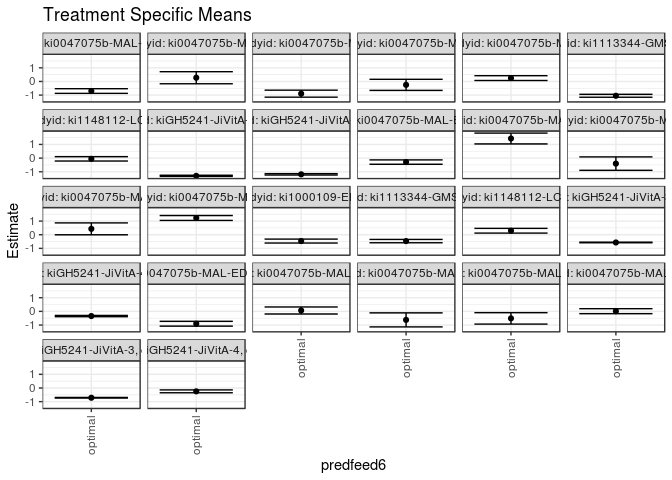

## Results Table

### Parameter: TSM

| agecat | studyid | country | intervention_level | baseline_level | estimate | ci_lower | ci_upper |
| --- | --- | --- | --- | --- | --- | --- | --- |
| Birth | ki0047075b-MAL-ED | BANGLADESH | optimal | observed | -0.9058073 | -1.0813956 | -0.7302190 |
| Birth | ki0047075b-MAL-ED | BRAZIL | optimal | observed | 0.0650986 | -0.1924500 | 0.3226472 |
| Birth | ki0047075b-MAL-ED | INDIA | optimal | observed | -0.6241304 | -1.1381648 | -0.1100961 |
| Birth | ki0047075b-MAL-ED | NEPAL | optimal | observed | -0.5134644 | -0.9322497 | -0.0946792 |
| Birth | ki0047075b-MAL-ED | PERU | optimal | observed | 0.0136885 | -0.1691414 | 0.1965185 |
| Birth | kiGH5241-JiVitA-3 | BANGLADESH | optimal | observed | -0.7155543 | -0.7368844 | -0.6942242 |
| Birth | kiGH5241-JiVitA-4 | BANGLADESH | optimal | observed | -0.2451818 | -0.3493325 | -0.1410310 |
| 6 months | ki0047075b-MAL-ED | BANGLADESH | optimal | observed | -0.2911598 | -0.4520961 | -0.1302236 |
| 6 months | ki0047075b-MAL-ED | BRAZIL | optimal | observed | 1.4343855 | 1.0377047 | 1.8310663 |
| 6 months | ki0047075b-MAL-ED | INDIA | optimal | observed | -0.4041817 | -0.8962710 | 0.0879077 |
| 6 months | ki0047075b-MAL-ED | NEPAL | optimal | observed | 0.4310173 | -0.0042613 | 0.8662958 |
| 6 months | ki0047075b-MAL-ED | PERU | optimal | observed | 1.2264519 | 1.0468407 | 1.4060630 |
| 6 months | ki1000109-EE | PAKISTAN | optimal | observed | -0.4635494 | -0.6067823 | -0.3203164 |
| 6 months | ki1113344-GMS-Nepal | NEPAL | optimal | observed | -0.4669861 | -0.5880892 | -0.3458829 |
| 6 months | ki1148112-LCNI-5 | MALAWI | optimal | observed | 0.2935440 | 0.1204939 | 0.4665941 |
| 6 months | kiGH5241-JiVitA-3 | BANGLADESH | optimal | observed | -0.5674090 | -0.5889932 | -0.5458247 |
| 6 months | kiGH5241-JiVitA-4 | BANGLADESH | optimal | observed | -0.3435175 | -0.3900683 | -0.2969667 |
| 24 months | ki0047075b-MAL-ED | BANGLADESH | optimal | observed | -0.7004874 | -0.8726852 | -0.5282895 |
| 24 months | ki0047075b-MAL-ED | BRAZIL | optimal | observed | 0.2748168 | -0.1667829 | 0.7164165 |
| 24 months | ki0047075b-MAL-ED | INDIA | optimal | observed | -0.8947047 | -1.1514675 | -0.6379418 |
| 24 months | ki0047075b-MAL-ED | NEPAL | optimal | observed | -0.2478609 | -0.6549094 | 0.1591876 |
| 24 months | ki0047075b-MAL-ED | PERU | optimal | observed | 0.2472641 | 0.0706997 | 0.4238285 |
| 24 months | ki1113344-GMS-Nepal | NEPAL | optimal | observed | -1.0485193 | -1.1548476 | -0.9421911 |
| 24 months | ki1148112-LCNI-5 | MALAWI | optimal | observed | -0.0549422 | -0.2146789 | 0.1047946 |
| 24 months | kiGH5241-JiVitA-3 | BANGLADESH | optimal | observed | -1.2992365 | -1.3407045 | -1.2577685 |
| 24 months | kiGH5241-JiVitA-4 | BANGLADESH | optimal | observed | -1.1877074 | -1.2372734 | -1.1381413 |

### Parameter: E(Y)

| agecat | studyid | country | intervention_level | baseline_level | estimate | ci_lower | ci_upper |
| --- | --- | --- | --- | --- | --- | --- | --- |
| Birth | ki0047075b-MAL-ED | BANGLADESH | observed | observed | -0.9925114 | -1.1346572 | -0.8503656 |
| Birth | ki0047075b-MAL-ED | BRAZIL | observed | observed | 0.4073214 | 0.2229599 | 0.5916830 |
| Birth | ki0047075b-MAL-ED | INDIA | observed | observed | -1.0435829 | -1.1865715 | -0.9005943 |
| Birth | ki0047075b-MAL-ED | NEPAL | observed | observed | -0.9226061 | -1.0630064 | -0.7822058 |
| Birth | ki0047075b-MAL-ED | PERU | observed | observed | -0.0430924 | -0.1600210 | 0.0738362 |
| Birth | kiGH5241-JiVitA-3 | BANGLADESH | observed | observed | -0.7234060 | -0.7433920 | -0.7034200 |
| Birth | kiGH5241-JiVitA-4 | BANGLADESH | observed | observed | -0.3738863 | -0.4580087 | -0.2897638 |
| 6 months | ki0047075b-MAL-ED | BANGLADESH | observed | observed | -0.1464929 | -0.2779745 | -0.0150113 |
| 6 months | ki0047075b-MAL-ED | BRAZIL | observed | observed | 0.9717225 | 0.8073791 | 1.1360658 |
| 6 months | ki0047075b-MAL-ED | INDIA | observed | observed | -0.7028736 | -0.8283047 | -0.5774424 |
| 6 months | ki0047075b-MAL-ED | NEPAL | observed | observed | 0.1167518 | -0.0146454 | 0.2481490 |
| 6 months | ki0047075b-MAL-ED | PERU | observed | observed | 1.0554461 | 0.9322755 | 1.1786167 |
| 6 months | ki1000109-EE | PAKISTAN | observed | observed | -0.7212766 | -0.8346857 | -0.6078675 |
| 6 months | ki1113344-GMS-Nepal | NEPAL | observed | observed | -0.6015049 | -0.6892785 | -0.5137313 |
| 6 months | ki1148112-LCNI-5 | MALAWI | observed | observed | 0.3927574 | 0.2737700 | 0.5117448 |
| 6 months | kiGH5241-JiVitA-3 | BANGLADESH | observed | observed | -0.5931801 | -0.6126929 | -0.5736674 |
| 6 months | kiGH5241-JiVitA-4 | BANGLADESH | observed | observed | -0.3971948 | -0.4378192 | -0.3565704 |
| 24 months | ki0047075b-MAL-ED | BANGLADESH | observed | observed | -0.8315789 | -0.9546058 | -0.7085521 |
| 24 months | ki0047075b-MAL-ED | BRAZIL | observed | observed | 0.4466272 | 0.2416144 | 0.6516401 |
| 24 months | ki0047075b-MAL-ED | INDIA | observed | observed | -0.9390848 | -1.0545919 | -0.8235777 |
| 24 months | ki0047075b-MAL-ED | NEPAL | observed | observed | -0.3703084 | -0.4835704 | -0.2570464 |
| 24 months | ki0047075b-MAL-ED | PERU | observed | observed | 0.1430051 | 0.0254144 | 0.2605957 |
| 24 months | ki1113344-GMS-Nepal | NEPAL | observed | observed | -1.1369520 | -1.2269975 | -1.0469065 |
| 24 months | ki1148112-LCNI-5 | MALAWI | observed | observed | -0.0771196 | -0.2204715 | 0.0662323 |
| 24 months | kiGH5241-JiVitA-3 | BANGLADESH | observed | observed | -1.2991319 | -1.3225545 | -1.2757094 |
| 24 months | kiGH5241-JiVitA-4 | BANGLADESH | observed | observed | -1.2337581 | -1.2679680 | -1.1995482 |

### Parameter: PAR

| agecat | studyid | country | intervention_level | baseline_level | estimate | ci_lower | ci_upper |
| --- | --- | --- | --- | --- | --- | --- | --- |
| Birth | ki0047075b-MAL-ED | BANGLADESH | optimal | observed | -0.0867041 | -0.2261332 | 0.0527250 |
| Birth | ki0047075b-MAL-ED | BRAZIL | optimal | observed | 0.3422228 | 0.1035985 | 0.5808471 |
| Birth | ki0047075b-MAL-ED | INDIA | optimal | observed | -0.4194524 | -0.9155244 | 0.0766195 |
| Birth | ki0047075b-MAL-ED | NEPAL | optimal | observed | -0.4091416 | -0.8015147 | -0.0167685 |
| Birth | ki0047075b-MAL-ED | PERU | optimal | observed | -0.0567809 | -0.2016958 | 0.0881341 |
| Birth | kiGH5241-JiVitA-3 | BANGLADESH | optimal | observed | -0.0078516 | -0.0159582 | 0.0002549 |
| Birth | kiGH5241-JiVitA-4 | BANGLADESH | optimal | observed | -0.1287045 | -0.2229897 | -0.0344193 |
| 6 months | ki0047075b-MAL-ED | BANGLADESH | optimal | observed | 0.1446669 | 0.0096939 | 0.2796399 |
| 6 months | ki0047075b-MAL-ED | BRAZIL | optimal | observed | -0.4626630 | -0.8280265 | -0.0972995 |
| 6 months | ki0047075b-MAL-ED | INDIA | optimal | observed | -0.2986919 | -0.7778599 | 0.1804761 |
| 6 months | ki0047075b-MAL-ED | NEPAL | optimal | observed | -0.3142655 | -0.7169138 | 0.0883828 |
| 6 months | ki0047075b-MAL-ED | PERU | optimal | observed | -0.1710058 | -0.3036022 | -0.0384093 |
| 6 months | ki1000109-EE | PAKISTAN | optimal | observed | -0.2577272 | -0.3584357 | -0.1570188 |
| 6 months | ki1113344-GMS-Nepal | NEPAL | optimal | observed | -0.1345188 | -0.2233357 | -0.0457019 |
| 6 months | ki1148112-LCNI-5 | MALAWI | optimal | observed | 0.0992133 | -0.0291208 | 0.2275475 |
| 6 months | kiGH5241-JiVitA-3 | BANGLADESH | optimal | observed | -0.0257711 | -0.0360186 | -0.0155237 |
| 6 months | kiGH5241-JiVitA-4 | BANGLADESH | optimal | observed | -0.0536773 | -0.0738584 | -0.0334962 |
| 24 months | ki0047075b-MAL-ED | BANGLADESH | optimal | observed | -0.1310916 | -0.2621158 | -0.0000674 |
| 24 months | ki0047075b-MAL-ED | BRAZIL | optimal | observed | 0.1718104 | -0.2133767 | 0.5569976 |
| 24 months | ki0047075b-MAL-ED | INDIA | optimal | observed | -0.0443801 | -0.3062054 | 0.2174452 |
| 24 months | ki0047075b-MAL-ED | NEPAL | optimal | observed | -0.1224475 | -0.4985875 | 0.2536925 |
| 24 months | ki0047075b-MAL-ED | PERU | optimal | observed | -0.1042590 | -0.2261791 | 0.0176610 |
| 24 months | ki1113344-GMS-Nepal | NEPAL | optimal | observed | -0.0884327 | -0.1587084 | -0.0181569 |
| 24 months | ki1148112-LCNI-5 | MALAWI | optimal | observed | -0.0221774 | -0.0876662 | 0.0433114 |
| 24 months | kiGH5241-JiVitA-3 | BANGLADESH | optimal | observed | 0.0001046 | -0.0359935 | 0.0362027 |
| 24 months | kiGH5241-JiVitA-4 | BANGLADESH | optimal | observed | -0.0460507 | -0.0856796 | -0.0064219 |